# Data Exploration mit Gapminder

2026-06-12

Ich übe hier die Plot-Sachen aus Kapitel 3 durch, aber auf dem Gapminder-Datensatz statt auf den Microarray-Daten aus dem Buch. Idee: jeden Code aus dem Kapitel einmal selbst auf eigene Daten anwenden, damit man die Funktionen wirklich kennt.

Die CSV ist mit Semikolon getrennt, deswegen `sep = ";"` (sonst landet alles in einer Spalte).

```r
df <- read.csv("gapminder-FiveYearData.csv", sep = ";")
library(ggplot2)
str(df)
```

```
## 'data.frame':    1704 obs. of  6 variables:
##  $ country  : chr  "Afghanistan" "Afghanistan" "Afghanistan" "Afghanistan" ...
##  $ year     : int  1952 1957 1962 1967 1972 1977 1982 1987 1992 1997 ...
##  $ pop      : num  8425333 9240934 10267083 11537966 13079460 ...
##  $ continent: chr  "Asia" "Asia" "Asia" "Asia" ...
##  $ lifeExp  : num  28.8 30.3 32 34 36.1 ...
##  $ gdpPercap: num  779 821 853 836 740 ...
```

Spalten: `country, year, pop, continent, lifeExp, gdpPercap`.

Wie das aufs Buch passt: `continent` ist die kategoriale Variable (im Buch `sampleGroup`), `lifeExp`/`gdpPercap`/`pop` sind die kontinuierlichen Messwerte (im Buch `density` bzw. die Expressionswerte), `year` ist Zeit. Praktisch: die Daten sind eh schon im long format (jede Zeile = ein Land in einem Jahr), das `melt`/`reshape` aus dem Buch brauche ich also gar nicht.

# 3.2 Basis-Grafik

Der Standard-`plot`. BIP gegen Lebenserwartung.

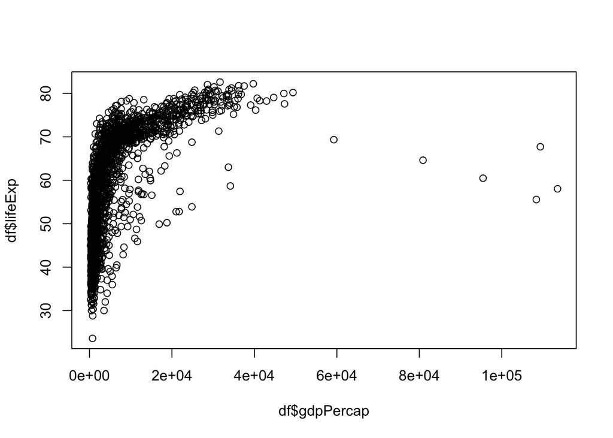

```r
plot(df$gdpPercap, df$lifeExp)
```

Dasselbe nochmal mit ordentlichen Achsen und anderem Symbol/Farbe:

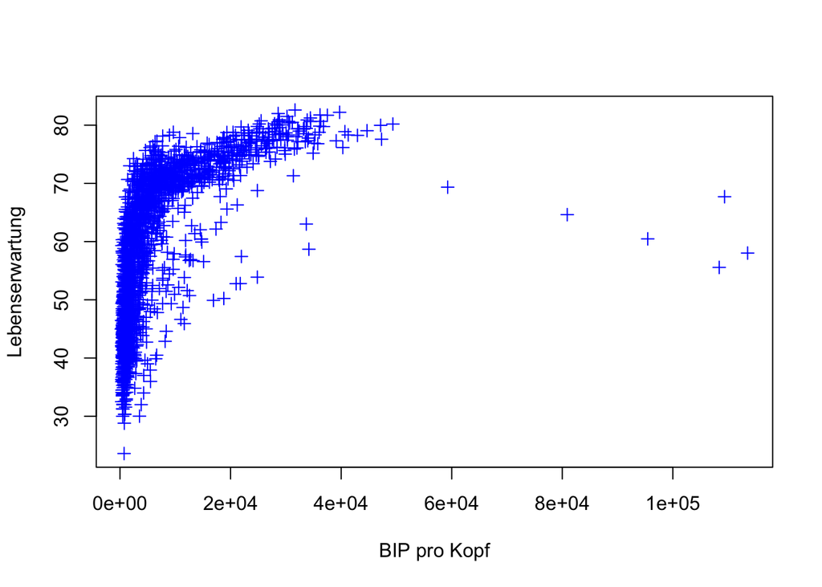

```r
plot(df$gdpPercap, df$lifeExp,
     xlab = "BIP pro Kopf", ylab = "Lebenserwartung",
     pch = 3, col = "blue")
```

Histogramm und Boxplot mit Bordmitteln. Boxplot hier nach Kontinent gruppiert (`~`).

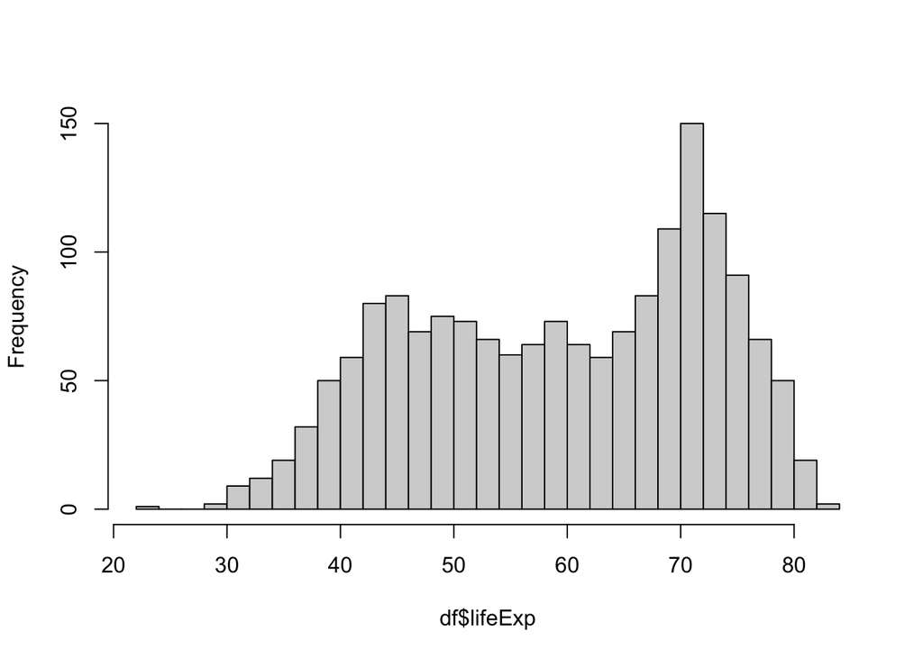

```r
hist(df$lifeExp, breaks = 25, main = "")
```

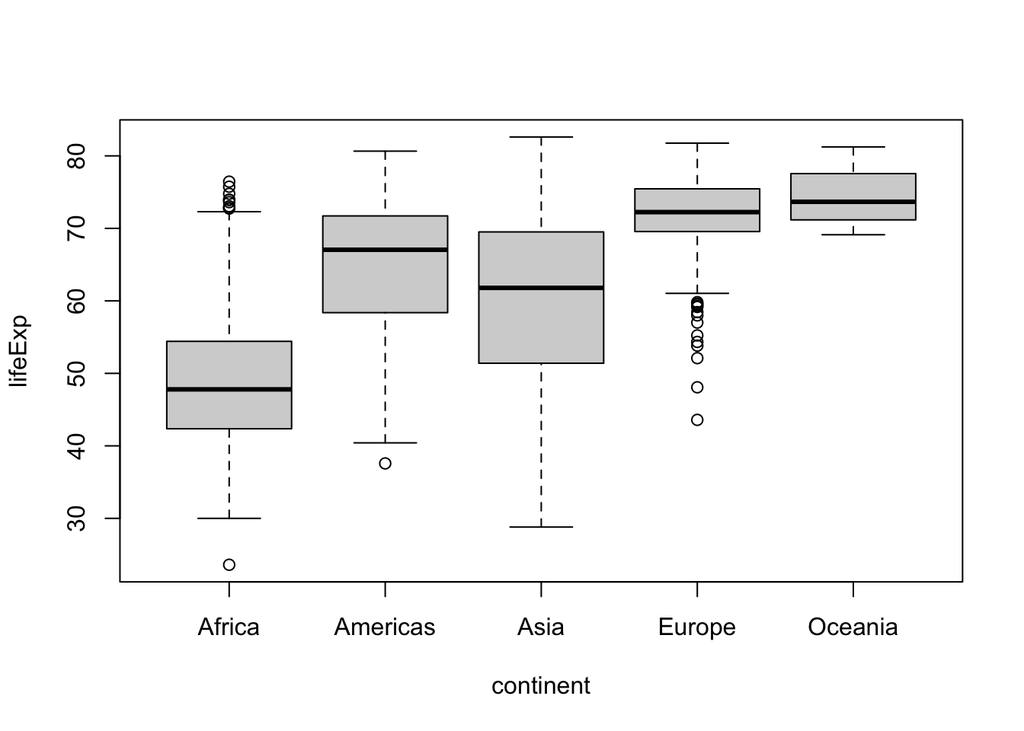

```r
boxplot(lifeExp ~ continent, data = df)
```